# COMPSCIX 415.2 Homework 5/Midterm

Claude Phan

3/5/19

My Github repository for my assignments can be found at this URL: https://github.com/claudephan/compscix-415-2-assignments.git

```r
library(mdsr)
library(tidyverse)
library(ggplot2)
library(nycflights13)
```

# The tidyverse packages

##### 1. Can you name which package is associated with each task below?

Plotting - ggplot2  
Data munging/wrangling - dplyr  
Reshaping (speading and gathering) data - tidyr  
Importing/exporting data - reader

##### 2. Now can you name two functions that you’ve used from each package that you listed above for these tasks?

Plotting - geom_histogram, geom_boxplot  
Data munging/wrangling - filter, mutate  
Reshaping data - gather, seperater  
Importing/exporting data - read_csv, read.table

# R Basics

##### 1. Fix this code with the fewest number of changes possible so it works: 2

```r
My_data.name_is.too00ooLong <- c( 1 , 2 , 3 )
My_data.name_is.too00ooLong
```

```
## [1] 1 2 3
```

##### 2. Fix this code so it works:

```r
my_string <- c('has', 'an', 'error', 'in', 'it')
my_string
```

```
## [1] "has"   "an"    "error" "in"    "it"
```

##### 3. Look at the code below and comment on what happened to the values in the vector.

```r
my_vector <- c(1, 2, '3', '4', 5)
my_vector
```

```
## [1] "1" "2" "3" "4" "5"
```

# Data import/export

##### 1. Download the rail_trail.txt file from Canvas (in the Midterm Exam section) and successfully import it into R. Prove that it was imported successfully by including your import code and taking a glimpse of the result.

```r
file_path <- 'rail_trail.txt'
rail_data <- read.table(file_path, sep = "|", header=TRUE)
glimpse(rail_data)
```

```
## Observations: 90
## Variables: 10
## $ hightemp   <int> 83, 73, 74, 95, 44, 69, 66, 66, 80, 79, 78, 65, 41, 5…
## $ lowtemp    <int> 50, 49, 52, 61, 52, 54, 39, 38, 55, 45, 55, 48, 49, 3…
## $ avgtemp    <dbl> 66.5, 61.0, 63.0, 78.0, 48.0, 61.5, 52.5, 52.0, 67.5,…
## $ spring     <int> 0, 0, 1, 0, 1, 1, 1, 1, 0, 0, 0, 1, 1, 0, 0, 1, 0, 1,…
## $ summer     <int> 1, 1, 0, 1, 0, 0, 0, 0, 1, 1, 1, 0, 0, 0, 0, 0, 1, 0,…
## $ fall       <int> 0, 0, 0, 0, 0, 0, 0, 0, 0, 0, 0, 0, 0, 1, 1, 0, 0, 0,…
## $ cloudcover <dbl> 7.6, 6.3, 7.5, 2.6, 10.0, 6.6, 2.4, 0.0, 3.8, 4.1, 8.…
## $ precip     <dbl> 0.00, 0.29, 0.32, 0.00, 0.14, 0.02, 0.00, 0.00, 0.00,…
## $ volume     <int> 501, 419, 397, 385, 200, 375, 417, 629, 533, 547, 432…
## $ weekday    <int> 1, 1, 1, 0, 1, 1, 1, 0, 0, 1, 1, 1, 1, 1, 1, 1, 0, 1,…
```

##### 2. Export the file into a comma-separated file and name it “rail_trail.csv”. Make sure you define the path correctly so that you know where it gets saved. Then reload the file. Include your export and import code and take another glimpse.

```r
write.csv(rail_data, file = "rail_trail.csv")
rail_data2 <- read_csv("rail_trail.csv")
glimpse(rail_data2)
```

```
## Observations: 90
## Variables: 11
## $ X1         <dbl> 1, 2, 3, 4, 5, 6, 7, 8, 9, 10, 11, 12, 13, 14, 15, 16…
## $ hightemp   <dbl> 83, 73, 74, 95, 44, 69, 66, 66, 80, 79, 78, 65, 41, 5…
## $ lowtemp    <dbl> 50, 49, 52, 61, 52, 54, 39, 38, 55, 45, 55, 48, 49, 3…
## $ avgtemp    <dbl> 66.5, 61.0, 63.0, 78.0, 48.0, 61.5, 52.5, 52.0, 67.5,…
## $ spring     <dbl> 0, 0, 1, 0, 1, 1, 1, 1, 0, 0, 0, 1, 1, 0, 0, 1, 0, 1,…
## $ summer     <dbl> 1, 1, 0, 1, 0, 0, 0, 0, 1, 1, 1, 0, 0, 0, 0, 0, 1, 0,…
## $ fall       <dbl> 0, 0, 0, 0, 0, 0, 0, 0, 0, 0, 0, 0, 0, 1, 1, 0, 0, 0,…
## $ cloudcover <dbl> 7.6, 6.3, 7.5, 2.6, 10.0, 6.6, 2.4, 0.0, 3.8, 4.1, 8.…
## $ precip     <dbl> 0.00, 0.29, 0.32, 0.00, 0.14, 0.02, 0.00, 0.00, 0.00,…
## $ volume     <dbl> 501, 419, 397, 385, 200, 375, 417, 629, 533, 547, 432…
## $ weekday    <dbl> 1, 1, 1, 0, 1, 1, 1, 0, 0, 1, 1, 1, 1, 1, 1, 1, 0, 1,…
```

# Visualization

1. It is hard to compare the counts against one another, there are too many of them to get an overall picture. Histograms should have been used.
2. There is also overlapping counts between gender and age group. It would have been better to include the gender within the age counts or vice verse by color coding the circles.
3. The data could be easier to read and compare if it was laid out horizontially rather than vertifcally.

##### 2. Reproduce this graphic using the diamonds data set.

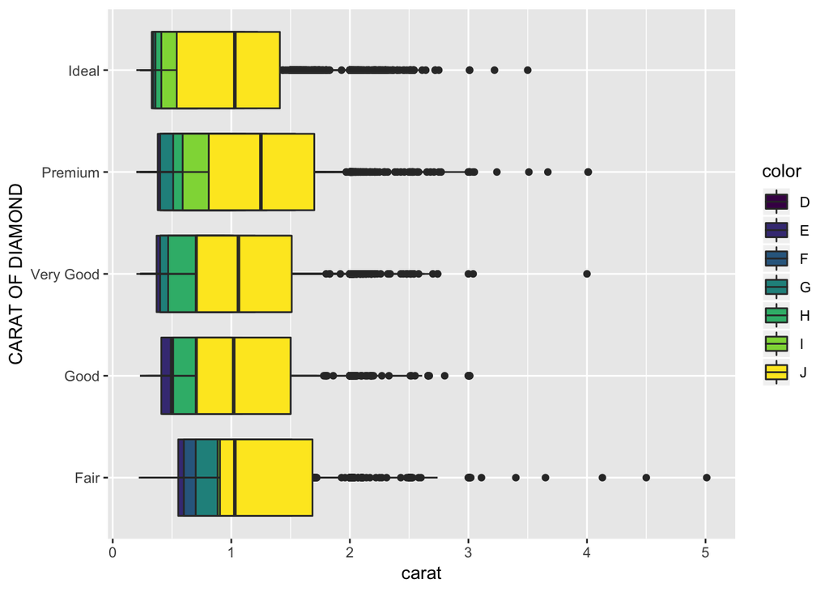

```r
ggplot(data = diamonds) +
  geom_boxplot(mapping = aes(x = cut, y = carat, fill = color), position = "identity") +
  xlab("CUT OF DIAMOND") +
  xlab("CARAT OF DIAMOND") +
  coord_flip()
```

##### 3. The previous graphic is not very useful. We can make it much more useful by changing one thing about it. Make the change and plot it again.

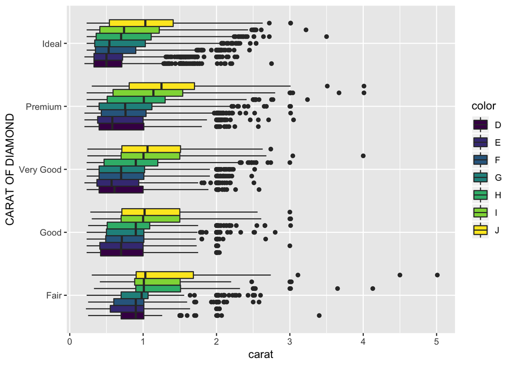

```r
ggplot(data = diamonds) +
  geom_boxplot(mapping = aes(x = cut, y = carat, fill = color), position = "dodge") +
  xlab("CUT OF DIAMOND") +
  xlab("CARAT OF DIAMOND") +
  coord_flip()
```

# Data munging and wrangling

##### 1. Is this data “tidy”? If yes, leave it alone and go to the next problem. If no, make it tidy. Note: this data set is called table2 and is available in the tidyverse package. It should be ready for you to use after you’ve loaded the tidyverse package.

```r
table2 %>%
    spread(key = type, value = count)
```

```
## # A tibble: 6 x 4
##   country      year  cases population
##   <chr>       <int>  <int>      <int>
## 1 Afghanistan  1999    745   19987071
## 2 Afghanistan  2000   2666   20595360
## 3 Brazil       1999  37737  172006362
## 4 Brazil       2000  80488  174504898
## 5 China        1999 212258 1272915272
## 6 China        2000 213766 1280428583
```

##### 2. Create a new column in the diamonds data set called price_per_carat that shows the price of each diamond per carat (hint: divide). Only show me the code, not the output.

diamonds %>% mutate(price_per_carart = price/carat)

##### 3. For each cut of diamond in the diamonds data set, how many diamonds, and what proportion, have a price > 10000 and a carat < 1.5? There are several ways to get to an answer, but your solution must use the data wrangling verbs from the tidyverse in order to get credit.

• Do the results make sense? Why?  
• Do we need to be wary of any of these numbers? Why?

These results make sense because we are filtering for diamonds that are very valuable but are not very big. Thus it make sense that these types of diamonds are of a better cut. I would be wary of the 4 diamoinds categorized as fair and the 17 as good cuts. They seem like they might have been mislabled.

```r
n_class <- diamonds %>% group_by(cut) %>% count()
x <- as.numeric(n_class$n)
n_filter <- diamonds %>%
  group_by(cut)%>%
  filter(price > 10000 & carat < 1.5) %>%
  summarize (count  = n()) %>%
  mutate (Total = x, proportion = (count/x))

n_filter
```

```
## # A tibble: 5 x 4
##   cut       count Total proportion
##   <ord>     <int> <dbl>      <dbl>
## 1 Fair          4  1610    0.00248
## 2 Good         17  4906    0.00347
## 3 Very Good   155 12082    0.0128
## 4 Premium     173 13791    0.0125
## 5 Ideal       485 21551    0.0225
```

# EDA

Take a look at the txhousing data set that is included with the ggplot2 package and answer these questions:

```r
glimpse(txhousing)
```

```
## Observations: 8,602
## Variables: 9
## $ city      <chr> "Abilene", "Abilene", "Abilene", "Abilene", "Abilene",…
## $ year      <int> 2000, 2000, 2000, 2000, 2000, 2000, 2000, 2000, 2000, …
## $ month     <int> 1, 2, 3, 4, 5, 6, 7, 8, 9, 10, 11, 12, 1, 2, 3, 4, 5, …
## $ sales     <dbl> 72, 98, 130, 98, 141, 156, 152, 131, 104, 101, 100, 92…
## $ volume    <dbl> 5380000, 6505000, 9285000, 9730000, 10590000, 13910000…
## $ median    <dbl> 71400, 58700, 58100, 68600, 67300, 66900, 73500, 75000…
## $ listings  <dbl> 701, 746, 784, 785, 794, 780, 742, 765, 771, 764, 721,…
## $ inventory <dbl> 6.3, 6.6, 6.8, 6.9, 6.8, 6.6, 6.2, 6.4, 6.5, 6.6, 6.2,…
## $ date      <dbl> 2000.000, 2000.083, 2000.167, 2000.250, 2000.333, 2000…
```

```r
df <- txhousing
```

##### 1. During what time period is this data from?

The data ranges from January 2000 to July 2015

```r
df2 <- txhousing %>%
  mutate ('YY-MM' = paste(year,"-",month))
head(sort(df2$`YY-MM`, decreasing=FALSE))
```

```
## [1] "2000 - 1" "2000 - 1" "2000 - 1" "2000 - 1" "2000 - 1" "2000 - 1"
```

##### 2. How many cities are represented?

46 Cities are represented

```r
unique(df$city)
```

```
##  [1] "Abilene"               "Amarillo"
##  [3] "Arlington"             "Austin"
##  [5] "Bay Area"              "Beaumont"
##  [7] "Brazoria County"       "Brownsville"
##  [9] "Bryan-College Station" "Collin County"
## [11] "Corpus Christi"        "Dallas"
## [13] "Denton County"         "El Paso"
## [15] "Fort Bend"             "Fort Worth"
## [17] "Galveston"             "Garland"
## [19] "Harlingen"             "Houston"
## [21] "Irving"                "Kerrville"
## [23] "Killeen-Fort Hood"     "Laredo"
## [25] "Longview-Marshall"     "Lubbock"
## [27] "Lufkin"                "McAllen"
## [29] "Midland"               "Montgomery County"
## [31] "Nacogdoches"           "NE Tarrant County"
## [33] "Odessa"                "Paris"
## [35] "Port Arthur"           "San Angelo"
## [37] "San Antonio"           "San Marcos"
## [39] "Sherman-Denison"       "South Padre Island"
## [41] "Temple-Belton"         "Texarkana"
## [43] "Tyler"                 "Victoria"
## [45] "Waco"                  "Wichita Falls"
```

##### 3. Which city, month and year had the highest number of sales?

The highest sales belongs to Houston in July 2015 with a count of 8945

```r
head(df[order(-df2$sales),])
```

```
## # A tibble: 6 x 9
##   city     year month sales     volume median listings inventory  date
##   <chr>   <int> <int> <dbl>      <dbl>  <dbl>    <dbl>     <dbl> <dbl>
## 1 Houston  2015     7  8945 2568156780 217600    23875       3.4 2016.
## 2 Houston  2006     6  8628 1795898108 155200    36281       5.6 2006.
## 3 Houston  2013     7  8468 2168720825 187800    21497       3.3 2014.
## 4 Houston  2015     6  8449 2490238594 222400    22311       3.2 2015.
## 5 Houston  2013     5  8439 2121508529 186100    20526       3.3 2013.
## 6 Houston  2014     6  8391 2342443127 211200    19725       2.9 2014.
```

##### 4. What kind of relationship do you think exists between the number of listings and the number of sales?

We can see by the graph below that there is a positive relationship between the number of listings and sales. The more listings you have the higher potential threre is to reach a higher number of sales.

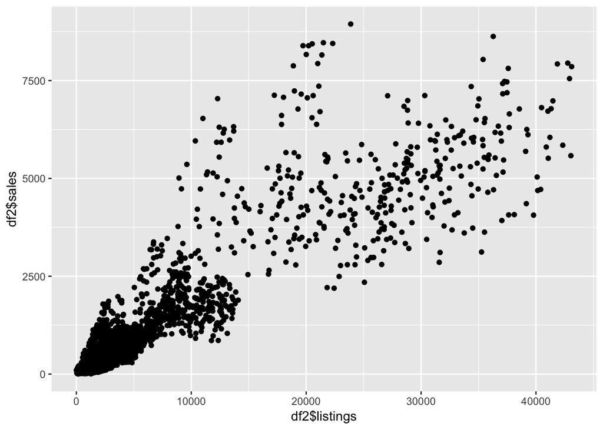

```r
ggplot(df2, aes(x=df2$listings, y=df2$sales)) +
  geom_point()
```

##### 5. What proportion of sales is missing for each city?

```r
n_per_city <- df2 %>% group_by(city) %>% count()
y <- as.numeric(n_per_city$n)

missing_sales <- df2 %>%
  group_by(city)%>%
  summarize (count  = n(), Num_missing = sum(is.na(sales))) %>%
  mutate (proportion = (Num_missing/y))

missing_sales
```

```
## # A tibble: 46 x 4
##    city                  count Num_missing proportion
##    <chr>                 <int>       <int>      <dbl>
##  1 Abilene                 187           0     0
##  2 Amarillo                187           0     0
##  3 Arlington               187           0     0
##  4 Austin                  187           0     0
##  5 Bay Area                187           0     0
##  6 Beaumont                187           0     0
##  7 Brazoria County         187          14     0.0749
##  8 Brownsville             187           2     0.0107
##  9 Bryan-College Station   187           0     0
## 10 Collin County           187           0     0
## # … with 36 more rows
```

##### 6. Looking at only the cities and months with greater than 500 sales:

• Are the distributions of the median sales price (column name median), when grouped by city, different? The same? Show your work.  
• Any cities that stand out that you’d want to investigate further?  
• Why might we want to filter out all cities and months with sales less than 500?

The boxplot below shows the distributions of the median sales peice, when grtouped by city. Not all the cities are the same, as expected. You can also see that some cities just produce more than 500 sales year round. Id like to investigate into Corpus Christi a bit more. They seem to be a city that doesn’t typically produce sales greater than 500, yet for 5 months throughout the time span, they were. It would be interesting to know why. We would want to filter out cities and months with sales less than 500 because they are probably not good representation of housing sales for the state of Texas. They could be small cities?

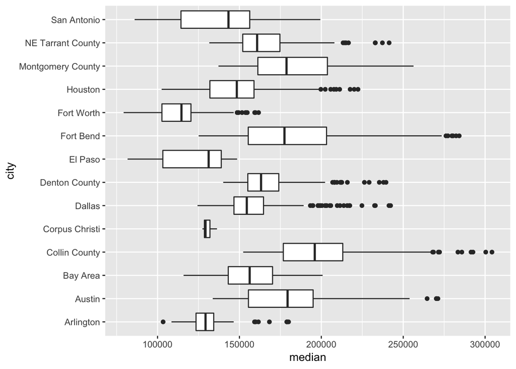

```r
df3 <- df2 %>%
  filter(sales > 500)

ggplot(data = df3) +
  geom_boxplot(mapping = aes(x = city, y = median), position = "identity") +
  coord_flip()
```

```r
z <- df3 %>%
  group_by(city)

table(z$city, z$month)
```

```
##
##                      1  2  3  4  5  6  7  8  9 10 11 12
##   Arlington          0  0  2  3 11  7  8  8  2  0  0  0
##   Austin            16 16 16 16 16 16 16 15 15 15 15 15
##   Bay Area           0  2  8  9 12 14 12 12  5  4  2  4
##   Collin County     14 16 16 16 16 16 16 15 15 15 15 15
##   Corpus Christi     0  0  0  0  1  2  1  1  0  0  0  0
##   Dallas            16 16 16 16 16 16 16 15 15 15 15 15
##   Denton County      1  7 14 15 16 16 15 14 12  9  7  8
##   El Paso            0  1  8 10  8  8  9  9  5  7  2  5
##   Fort Bend          7 14 16 16 16 16 16 15 15 15 15 15
##   Fort Worth         7 12 16 15 16 16 16 15 15 15 15 14
##   Houston           16 16 16 16 16 16 16 15 15 15 15 15
##   Montgomery County  1  4 11 11 13 13 14 12  9  7  6  7
##   NE Tarrant County  2 12 16 16 16 16 16 15 14 13 12 10
##   San Antonio       16 16 16 16 16 16 16 15 15 15 15 15
```